# report

REPORT

전체적으로 petal length는 setosa < versicolor < virginica 순으로 크며, 종 간의 차이가 명확하다.

$2$. 정규성 검정

H0 : 데이터는 정규분포를 따른다.  
H1 : 데이터는 정규분포를 따르지 않는다.

검정 결과 p value는 : setosa - 0.055>0.05, versicolor = 0.158 > 0.05 , virginica = 0.110>0.05로 세 종 모두 H0를 채택한다.

즉, 세 종은 모두 정규분포를 따른다는 결론을 얻을 수 있다.

$3$. 등분산성 검정  
H0 : 세 집단의 분산은 같다.  
H1 : 적어도 한 그룹의 분산은 다르다.

검정 결과 pvalue는 0.05보다 작다. 즉, H0 기각 -> 적어도 한 그룹의 분산은 다름을 알 수 있다.

$4$. Anova 검정

H0 : 세 species 간 평균은 동일하다.  
H1 : 적어도 한 집단의 평균은 다르다.

검정 결과 P VALUE는 2.8567766109615584e-91<0.05로 H0 기각. 즉, 적어도 한 그룹의 평균은 다르다.

$5$. Turkey-HSD 사후검정

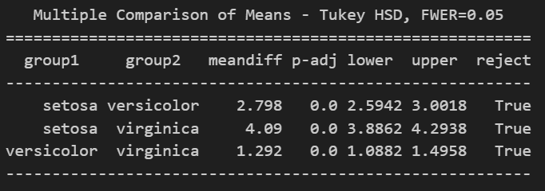

(1) setosa - versicolor  
평균의 차는 2.798이고, p-val < 0.05, reject TRUE이므로 유의미한 차이가 존재한다.

(2) setosa - virginica  
평균의 차는 4.09이고, p-val < 0.05, reject TRUE이므로 유의미한 차이가 존재한다.

종합하면, 세 species 간 petal_length의 mean은 모든 쌍에서 유의미한 차이를 보인다.

$6$. 결과 요약

(2) Anova 결과 p-value가 0.05보다 작아 귀무가설 기각 즉, 세 개의 species 간 평균 차이가 통계적으로 유의미한 것으로 확인되었다.

(3) Turkey HSD 사후검정  
모든 쌍에서 유의미한 차이를 보였다.

1, 2, 3의 결과를 종합할 때  
virginica의 length가 통계적으로 유의하게 길며  
setosa의 length가 통계적으로 유의하게 짧다.

또한 세 종의 petal length는 통계적으로 유의하게 차이가 난다고 할 수 있다.

$7$. 회귀분석

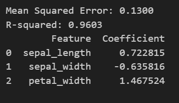

해석 : mse는 0.13정도로, 예측값과 실제값 간의 오차가 비교적 작음을 알 수 있다. R^2는 0.96으로, 이 모형은 petal_length의 약 96%를 설명하고 있어 매우 높은 설명력을 가진다.

또한 다른 변수들이 고정되어 있다는 가정 하에, sepal_length가 1 증가할 때 petal_length는 약 0.72만큼 증가하는 경향을 sepal_width가 1 증가할 때 petal_length는 약 0.64만큼 감소하는 경향을 petal_width가 1 증가할 때 petal_length는 약 1.47만큼 증가하는 경향을 보였다. 종합하면 petal_width가 petal_length를 설명하는 데 가장 중요한 변수이다.